# Asiye Demir Project A

Asiye Demir

01/30/2021

### Description

Gun violence or ownership has been a ongoing debate in the United States. Although the legal debate and regulations have changed over time, a gun can be a reason for somebody’s death. In this report, I will examine the gun deaths in America by looking at the proportions in the intention, gender and race factors behind the gun death across years.

Data Source: [Five Thirty Eight](https://fivethirtyeight.com/features/gun-deaths/)

### Analysis

As a first step, I looked the proportions in the intent of gun death in 2012. As Table 1 and Figure 1 show, the most indented reason for gun use is suicide (.62) in 2012. Using a gun for homicidal purpose has the second place with .36 proportion.

```r
library(tidyverse)
library(knitr)
library(kableExtra)
library(ggplot2)
library(magrittr)

guns<-read.csv("full_data.csv")
```

```r
death2012<-subset(guns, guns$year == "2012")
```

```r
More_death2012<- death2012 %>%
  group_by(intent) %>%
  summarize (freq = n()) %>%
  mutate (prop = freq/sum(freq))
death2012 %>%
  group_by(intent) %>%
  summarize(freq = n()) %>%
  mutate (prop = freq/sum(freq))
```

| intent | freq | prop |
| --- | --- | --- |
| Accidental | 548 | 0.016327504 |
| Homicide | 12093 | 0.360307481 |
| Suicide | 20666 | 0.615737568 |
| Undetermined | 256 | 0.007627447 |

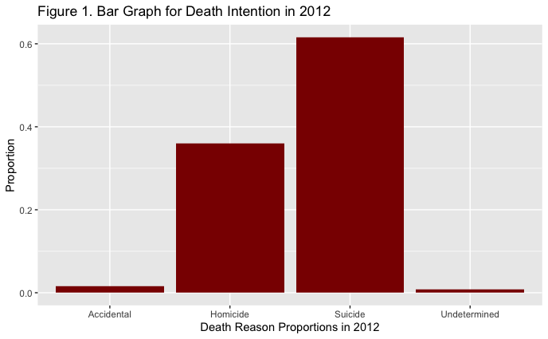

```r
ggplot(More_death2012, aes (x = intent, y = prop)) +
  geom_col(fill = "red4") +
  labs (x = "Death Reason Proportions in 2012",
        y = "Proportion",
        title = "Figure 1. Bar Graph for Death Intention in 2012")
```

```r
More_death2012 %>%
  knitr::kable(caption = "Table 1. Proportions for Intent of Gun Death in 2012", digits = 4) %>%
  kableExtra::kable_styling(bootstrap_options = "striped")
```

Table 1. Proportions for Intent of Gun Death in 2012

| intent | freq | prop |
| --- | --- | --- |
| Accidental | 548 | 0.0163 |
| Homicide | 12093 | 0.3603 |
| Suicide | 20666 | 0.6157 |
| Undetermined | 256 | 0.0076 |

```r
More_gender2012<- death2012 %>%
  group_by(sex) %>%
  summarize (freq = n()) %>%
  mutate (prop = freq/sum(freq))
death2012 %>%
  group_by(sex) %>%
  summarize(freq = n()) %>%
  mutate (prop = freq/sum(freq))
```

| sex | freq | prop |
| --- | --- | --- |
| F | 4725 | 0.14078 |
| M | 28838 | 0.85922 |

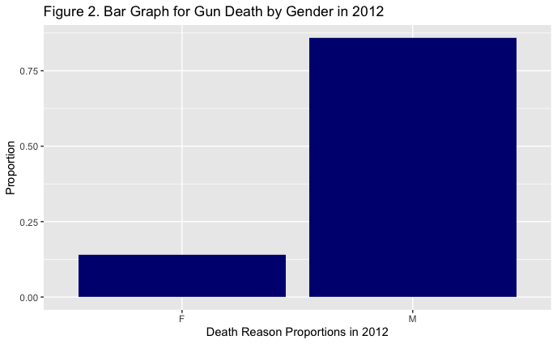

```r
ggplot(More_gender2012, aes (x = sex, y = prop)) +
  geom_col(fill = "navy") +
  labs (x = "Death Reason Proportions in 2012",
        y = "Proportion",
        title = "Figure 2. Bar Graph for Gun Death by Gender in 2012")
```

Gun death in 2012 was observed mostly among men than women. Men constitutes 86% of the sample while women constitutes only 14%.

```r
More_race2012<- death2012 %>%
  group_by(race) %>%
  summarize (freq = n()) %>%
  mutate (prop = freq/sum(freq))
death2012 %>%
  group_by(race) %>%
  summarize(freq = n()) %>%
  mutate (prop = freq/sum(freq))
```

| race | freq | prop |
| --- | --- | --- |
| Asian/Pacific Islander | 453 | 0.013497006 |
| Black | 7946 | 0.236748801 |
| Hispanic | 3061 | 0.091201621 |
| Native American/Native Alaskan | 310 | 0.009236361 |
| White | 21793 | 0.649316211 |

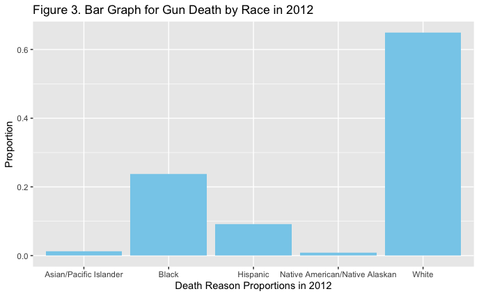

```r
ggplot(More_race2012, aes (x = race, y = prop)) +
  geom_col(fill = "skyblue") +
  labs (x = "Death Reason Proportions in 2012",
        y = "Proportion",
        title = "Figure 3. Bar Graph for Gun Death by Race in 2012")
```

```r
More_race2012<- death2012 %>%
  group_by(race) %>%
  summarize (freq = n()) %>%
  mutate (prop = freq/sum(freq))
death2012 %>%
  group_by(race) %>%
  summarize(freq = n()) %>%
  mutate (prop = freq/sum(freq))
```

| race | freq | prop |
| --- | --- | --- |
| Asian/Pacific Islander | 453 | 0.013497006 |
| Black | 7946 | 0.236748801 |
| Hispanic | 3061 | 0.091201621 |
| Native American/Native Alaskan | 310 | 0.009236361 |
| White | 21793 | 0.649316211 |

```r
More_race2012 %>%
  knitr::kable(caption = "Table 3. Proportions for Gun Death by Race in 2012", digits = 5) %>%
  kableExtra::kable_styling(bootstrap_options = "striped")
```

Table 3. Proportions for Gun Death by Race in 2012

| race | freq | prop |
| --- | --- | --- |
| Asian/Pacific Islander | 453 | 0.01350 |
| Black | 7946 | 0.23675 |
| Hispanic | 3061 | 0.09120 |
| Native American/Native Alaskan | 310 | 0.00924 |
| White | 21793 | 0.64932 |

The last variable of interest in my report is race frequency in the gun death in 2012. Among 5 different race class, white death due to gun is overwhelmingly high. (.65). More than half of the gun death cases contain white people. Black people follows white frequency with about .25. Remaining 10 percent is shared among Asian, Native American and Hispanic people.